# Проект "Принятие решений в бизнесе" . Приоритизация гипотез и анализ А/ В теста

Отдел маркетинга совместно с аналитиками крупного интернет-магазина подготовили список гипотез для увеличения выручки. Нам нужно приоритизировать гипотезы. Затем запустить А/В тест и проанализировать его результаты.

```python
import pandas as pd
import scipy.stats as stats
import datetime as dt
import numpy as np
import math as mth
import matplotlib.pyplot as plt
from pandas.plotting import register_matplotlib_converters
import warnings
warnings.filterwarnings('ignore')

register_matplotlib_converters()
```

```python
pd.set_option('display.max_columns', None)
pd.options.display.max_colwidth = 150
```

## Часть 1. Приоритизация гипотез

### Обзор данных

Посмотри на данные гипотез по увеличению выручки.

```python
data = pd.read_csv('hypothesis.csv')
data.info()
```

```
<class 'pandas.core.frame.DataFrame'>
RangeIndex: 9 entries, 0 to 8
Data columns (total 5 columns):
 #   Column      Non-Null Count  Dtype
---  ------      --------------  -----
 0   Hypothesis  9 non-null      object
 1   Reach       9 non-null      int64
 2   Impact      9 non-null      int64
 3   Confidence  9 non-null      int64
 4   Efforts     9 non-null      int64
dtypes: int64(4), object(1)
memory usage: 488.0+ bytes
```

Таблица содержит 9 строк и 5 столбцов. Форматы столбцов соответствуют описанию данных (столбец с названиями гипотез содержит строковые значения, а столбцы с оценками параметров приоритизации - целочисленные).

Для соблюдения хорошего стиля приведем названия столбцов к нижнему регистру.

```python
data.columns = data.columns.str.lower()
data.columns
```

```
Index(['hypothesis', 'reach', 'impact', 'confidence', 'efforts'], dtype='object')
```

```python
data
```

|  | hypothesis | reach | impact | confidence | efforts |
| --- | --- | --- | --- | --- | --- |
| 0 | Добавить два новых канала привлечения трафика, что позволит привлекать на 30% больше пользователей | 3 | 10 | 8 | 6 |
| 1 | Запустить собственную службу доставки, что сократит срок доставки заказов | 2 | 5 | 4 | 10 |
| 2 | Добавить блоки рекомендаций товаров на сайт интернет магазина, чтобы повысить конверсию и средний чек заказа | 8 | 3 | 7 | 3 |
| 3 | Изменить структура категорий, что увеличит конверсию, т.к. пользователи быстрее найдут нужный товар | 8 | 3 | 3 | 8 |
| 4 | Изменить цвет фона главной страницы, чтобы увеличить вовлеченность пользователей | 3 | 1 | 1 | 1 |
| 5 | Добавить страницу отзывов клиентов о магазине, что позволит увеличить количество заказов | 3 | 2 | 2 | 3 |
| 6 | Показать на главной странице баннеры с актуальными акциями и распродажами, чтобы увеличить конверсию | 5 | 3 | 8 | 3 |
| 7 | Добавить форму подписки на все основные страницы, чтобы собрать базу клиентов для email-рассылок | 10 | 7 | 8 | 5 |
| 8 | Запустить акцию, дающую скидку на товар в день рождения | 1 | 9 | 9 | 5 |

**Вывод**

Таблица содержит 9 гипотез и 4 параметра для их приоритизации (Reach, Impact, Confidence, Efforts). Оценка параметров приведена в значениях по шкале от 1 до 10.

В ходе обзора мы выявили нарушение в стиле заголовков и испарвили его, для удобства дальнейшей работы.

### Приоритизация гипотез при помощи фреймворка ICE

Рассчитаем ICE для каждой гипотезы. Добавим соответствующий столбец к таблице.

```python
data['ice'] = round(data['impact'] * data['confidence'] / data['efforts'], 2)

data[['hypothesis', 'ice']].sort_values(by='ice', ascending=False)
```

|  | hypothesis | ice |
| --- | --- | --- |
| 8 | Запустить акцию, дающую скидку на товар в день рождения | 16.20 |
| 0 | Добавить два новых канала привлечения трафика, что позволит привлекать на 30% больше пользователей | 13.33 |
| 7 | Добавить форму подписки на все основные страницы, чтобы собрать базу клиентов для email-рассылок | 11.20 |
| 6 | Показать на главной странице баннеры с актуальными акциями и распродажами, чтобы увеличить конверсию | 8.00 |
| 2 | Добавить блоки рекомендаций товаров на сайт интернет магазина, чтобы повысить конверсию и средний чек заказа | 7.00 |
| 1 | Запустить собственную службу доставки, что сократит срок доставки заказов | 2.00 |
| 5 | Добавить страницу отзывов клиентов о магазине, что позволит увеличить количество заказов | 1.33 |
| 3 | Изменить структура категорий, что увеличит конверсию, т.к. пользователи быстрее найдут нужный товар | 1.12 |
| 4 | Изменить цвет фона главной страницы, чтобы увеличить вовлеченность пользователей | 1.00 |

Самые перспективные гипотезы при применении параметров фреймворка ICE - это гипотезы с индексами строк 8, 0, 7 :

### Приоритизация гипотез при помощи фреймворка RICE

Рассчитаем RICE для каждой гипотезы. Добавим соответствующий столбец к таблице.

```python
data['rice'] = round(data['reach'] * data['impact'] * data['confidence'] / data['efforts'], 5)
data[['hypothesis', 'ice', 'rice']] .sort_values(by='rice', ascending=False)
```

|  | hypothesis | ice | rice |
| --- | --- | --- | --- |
| 7 | Добавить форму подписки на все основные страницы, чтобы собрать базу клиентов для email-рассылок | 11.20 | 112.0 |
| 2 | Добавить блоки рекомендаций товаров на сайт интернет магазина, чтобы повысить конверсию и средний чек заказа | 7.00 | 56.0 |
| 0 | Добавить два новых канала привлечения трафика, что позволит привлекать на 30% больше пользователей | 13.33 | 40.0 |
| 6 | Показать на главной странице баннеры с актуальными акциями и распродажами, чтобы увеличить конверсию | 8.00 | 40.0 |
| 8 | Запустить акцию, дающую скидку на товар в день рождения | 16.20 | 16.2 |
| 3 | Изменить структура категорий, что увеличит конверсию, т.к. пользователи быстрее найдут нужный товар | 1.12 | 9.0 |
| 1 | Запустить собственную службу доставки, что сократит срок доставки заказов | 2.00 | 4.0 |
| 5 | Добавить страницу отзывов клиентов о магазине, что позволит увеличить количество заказов | 1.33 | 4.0 |
| 4 | Изменить цвет фона главной страницы, чтобы увеличить вовлеченность пользователей | 1.00 | 3.0 |

При применении параметров фреймворка RICE наиболее перспективной определилась гипотеза с индексом 7, на втором месте гипотеза с индексом строки 2, на третьем - 0 и 6.

- Добавить форму подписки на все основные страницы, чтобы собрать базу клиентов для email-рассылок
- Добавить блоки рекомендаций товаров на сайт интернет магазина, чтобы повысить конверсию и средний чек заказа
- Добавить два новых канала привлечения трафика, что позволит привлекать на 30% больше пользователей
- Показать на главной странице баннеры с актуальными акциями и распродажами, чтобы увеличить конверсию

Рейтинг гипотез по фреймворку RICE отличается от рейтинга ICE, потому что RICE, помимо влияния, уверенности и усилий, учитывает еще и охват пользователей предлагаемым изменением. В данном случае у гипотезы с индексом строки 7 ("Добавить форму подписки на все основные страни...") самый высокий охват пользователей (10 - фактически это изменение затронет всех пользователей интернет-магазина). А у гипотезы, которая вышла на первое место при применении фреймворка ICE с индексом строки 8 ("Запустить акцию, дающую скидку на товар в день...") не смотря на максимальные значения уверенности и влияния на пользователй, охват пользователей минимальный (показатель 1).

### Вывод.

Для проведения A/B теста можно рекомендовать гипотезу с индексом строки 7 - "Добавить форму подписки на все основные страницы, чтобы собрать базу клиентов для email-рассылок". У этого изменения максимальный охват пользователей, а также высокие показатели уровня влияния на пользователей и уверенности в этом влиянии. Сложность тестирования данной гипотезы находится на среднем уровне.

## Часть 2. Анализ А/В теста.

### Обзор данных.

Посмотрим на таблицы с данными результатов А/В теста.

```python
orders = pd.read_csv('orders.csv')
visitors = pd.read_csv('visitors.csv')
```

```python
orders.info()
print('\n')
visitors.info()
```

```
<class 'pandas.core.frame.DataFrame'>
RangeIndex: 1197 entries, 0 to 1196
Data columns (total 5 columns):
 #   Column         Non-Null Count  Dtype
---  ------         --------------  -----
 0   transactionId  1197 non-null   int64
 1   visitorId      1197 non-null   int64
 2   date           1197 non-null   object
 3   revenue        1197 non-null   int64
 4   group          1197 non-null   object
dtypes: int64(3), object(2)
memory usage: 46.9+ KB


<class 'pandas.core.frame.DataFrame'>
RangeIndex: 62 entries, 0 to 61
Data columns (total 3 columns):
 #   Column    Non-Null Count  Dtype
---  ------    --------------  -----
 0   date      62 non-null     object
 1   group     62 non-null     object
 2   visitors  62 non-null     int64
dtypes: int64(1), object(2)
memory usage: 1.6+ KB
```

Согласно описанию проекта

файл `orders` содержит следующую информацию:

- `transactionId` — идентификатор заказа;
- `visitorId` — идентификатор пользователя, совершившего заказ;
- `date` — дата, когда был совершён заказ;
- `revenue` — выручка заказа;
- `group` — группа A/B-теста, в которую попал заказ;

Файл `visitors` включает данные:

- `date` — дата;
- `group` — группа A/B-теста;
- `visitors` — количество пользователей в указанную дату в указанной группе A/B-теста.

Приведем данные, содержащие дату к формату `datetime`

```python
orders['date'] = pd.to_datetime (orders['date']).dt.date
visitors['date'] = pd.to_datetime (visitors['date']).dt.date
```

Названия столбцов в таблице `orders` приведем к "змеиному регистру" (без заглавных букв и пробелов)

```python
orders = orders.rename(columns={'transactionId': 'transaction_id', 'visitorId': 'visitor_id'})
```

Провирим таблицы на наличие полных дубликатов

```python
orders.duplicated().sum()
```

```
0
```

```python
visitors.duplicated().sum()
```

```
0
```

Полных дубликатов строк в таблицах нет.

Выведем первые строки имеющихся таблиц

```python
orders.head()
```

|  | transaction_id | visitor_id | date | revenue | group |
| --- | --- | --- | --- | --- | --- |
| 0 | 3667963787 | 3312258926 | 2019-08-15 | 1650 | B |
| 1 | 2804400009 | 3642806036 | 2019-08-15 | 730 | B |
| 2 | 2961555356 | 4069496402 | 2019-08-15 | 400 | A |
| 3 | 3797467345 | 1196621759 | 2019-08-15 | 9759 | B |
| 4 | 2282983706 | 2322279887 | 2019-08-15 | 2308 | B |

```python
visitors.head()
```

|  | date | group | visitors |
| --- | --- | --- | --- |
| 0 | 2019-08-01 | A | 719 |
| 1 | 2019-08-02 | A | 619 |
| 2 | 2019-08-03 | A | 507 |
| 3 | 2019-08-04 | A | 717 |
| 4 | 2019-08-05 | A | 756 |

Проверим уникальность пользователей, сделавших заказы по группам.

```python
print(
    'Всего в тесте сделали заказы', orders['visitor_id'].nunique(), 'уникальных пользователей\n',
    'В группе А сделали заказы', orders.query('group == "A"')['visitor_id'].nunique(), 'пользователей\n',
    'В группе B сделали заказы', orders.query('group == "B"')['visitor_id'].nunique(), 'пользователей\n'
)
print(
    'Данные содержат',
    orders.groupby(by='visitor_id')
    .agg({'group' : 'nunique'}).reset_index().query('group == 2').visitor_id.nunique(),
    'уникальных пользователей, чьи заказы попали в обе группы теста.\n'
)

print(
    ' Процент пересекающихся пользователей в группе А - ',
    round(
        orders.groupby(by='visitor_id')
        .agg({'group' : 'nunique'}).reset_index().query('group == 2').visitor_id.nunique()/
        orders.query('group == "A"')['visitor_id'].nunique() * 100, 2
    ),
    '\n',
    'Процент пересекающихся пользователей в группе B - ',
    round(
        orders.groupby(by='visitor_id')
        .agg({'group' : 'nunique'}).reset_index().query('group == 2').visitor_id.nunique()/
        orders.query('group == "B"')['visitor_id'].nunique() * 100, 2
    )
)
```

```
Всего в тесте сделали заказы 1031 уникальных пользователей
 В группе А сделали заказы 503 пользователей
 В группе B сделали заказы 586 пользователей

Данные содержат 58 уникальных пользователей, чьи заказы попали в обе группы теста.

 Процент пересекающихся пользователей в группе А -  11.53
 Процент пересекающихся пользователей в группе B -  9.9
```

Проверим долю выручки и количество заказов таких пользователей по каждой группе

```python
visitor_in_ab =(
    orders.groupby(by='visitor_id')
    .agg({'group' : 'nunique'})
    .reset_index().
    query('group == 2')
    .visitor_id.unique()
)

orders_ab_total =(
    orders.groupby(by='group', as_index=False)
    .agg({'revenue': 'sum', 'transaction_id': 'nunique'})
)
orders_ab_total.columns=['group', 'revenue', 'transactions']

orders_visitors_in_a_and_b = (
    orders.query('visitor_id in @visitor_in_ab')
    .groupby(by='group', as_index=False)
    .agg({'revenue': 'sum', 'transaction_id': 'nunique'})
)
orders_visitors_in_a_and_b.columns=['group', 'revenue_visitors_in_ab', 'transactions_in_ab']

orders_ab = orders_ab_total.merge(orders_visitors_in_a_and_b, on='group', how='left')

orders_ab['%_revenue_visitors_in_ab'] = (orders_ab['revenue_visitors_in_ab'] / orders_ab['revenue'] * 100).round(2)
orders_ab['%_transactions_in_ab'] = (orders_ab['transactions_in_ab'] / orders_ab['transactions'] * 100).round(2)

orders_ab
```

|  | group | revenue | transactions | revenue_visitors_in_ab | transactions_in_ab | %_revenue_visitors_in_ab | %_transactions_in_ab |
| --- | --- | --- | --- | --- | --- | --- | --- |
| 0 | A | 4084803 | 557 | 720147 | 89 | 17.63 | 15.98 |
| 1 | B | 5907760 | 640 | 838788 | 92 | 14.20 | 14.37 |

**Вывод**

Для анализа А/В теста нам предоставлены две таблицы с данными. Одна из которых `orders` содержит информацию о заказах пользователях, другая `visitors` о количестве визитов пользователей каждой группы по дням.

В ходе предобработки были обнаружены следующие проблемы с данными:

- нарушения в стиле заголовков (названия столбцов записаны с использованием двух регистров)
- несоответствие типов данных - данные содержащие дату, сохранены в формате `object` Названия столбцов привели к нижнему регистру и записали в "змеином регистре". Столбцы, содержащие дату привели к формату `datetime`

Кроме того, мы выяснили, что данные содержат 58 пользователей, чьи заказы попали в обе группы А/В теста. Доля выручки таких пользователей в группе А составляет 17,65, в группе В - 14,2%, а доля в количестве заказов у группы А - 16%, у группы В - 14,4%. Что составляет существенную часть выборки. Наличие таких пользователей может привести к искажению результатов А/В теста. Их удаление также может привести к ошибочным результатам.

В целом, в этом случае следует провести А/В тест повторно, исправив технические ошибки, которые привели к появлению пересекающихся пользователей. Но так как у нас нет такой возможности, проведем анализ A/B теста на основе имеющихся данных.

### Создание таблицы с кумулятивными данными.

Для анализа куммулятивных данных по группам создадим таблицу с ними.

Массив уникальных значений дат и групп.

```python
dates_groups = orders[['date','group']].drop_duplicates()

orders_aggregated = (
    dates_groups
    .apply(
        lambda x: orders[
            np.logical_and(orders['date'] <= x['date'], orders['group'] == x['group'])
        ]
        .agg(
            {'date' : 'max', 'group' : 'max', 'transaction_id' : 'nunique', 'visitor_id' : 'nunique', 'revenue' : 'sum'}
        ), axis=1
    ).sort_values(by=['date','group'])
)

visitors_aggregated = (
    dates_groups
    .apply(
        lambda x: visitors[
            np.logical_and(visitors['date'] <= x['date'], visitors['group'] == x['group'])
        ].agg(
            {'date' : 'max', 'group' : 'max', 'visitors' : 'sum'}
        ), axis=1
    ).sort_values(by=['date','group'])
)

cumulative_data = orders_aggregated.merge(visitors_aggregated, on=['date', 'group'])
cumulative_data.columns = ['date', 'group', 'orders', 'buyers', 'revenue', 'visitors']
```

```python
cumulative_data.head()
```

|  | date | group | orders | buyers | revenue | visitors |
| --- | --- | --- | --- | --- | --- | --- |
| 0 | 2019-08-01 | A | 24 | 20 | 148579 | 719 |
| 1 | 2019-08-01 | B | 21 | 20 | 101217 | 713 |
| 2 | 2019-08-02 | A | 44 | 38 | 242401 | 1338 |
| 3 | 2019-08-02 | B | 45 | 43 | 266748 | 1294 |
| 4 | 2019-08-03 | A | 68 | 62 | 354874 | 1845 |

### График кумулятивной выручки по группам А/В тестирования.

Отфильтруем данные для построения графика по группам А и В

```python
cumulative_data_а = cumulative_data[cumulative_data['group'] == 'A'][['date', 'orders', 'revenue']]
cumulative_data_b = cumulative_data[cumulative_data['group'] == 'B'][['date', 'orders', 'revenue']]
```

Построим графики комулятивной выручки.

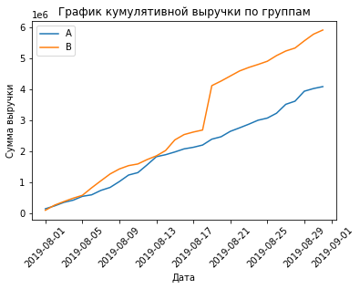

```python
plt.plot(cumulative_data_а['date'], cumulative_data_а['revenue'], label='A')
plt.plot(cumulative_data_b['date'], cumulative_data_b['revenue'], label='B')
plt.title('График кумулятивной выручки по группам')
plt.xticks(rotation=45)
plt.legend()
plt.xlabel('Дата')
plt.ylabel('Сумма выручки')
plt.show()
```

В целом выручка по группе А равномерно растет в течении всего периода. До 5 августа выручки по обоим группам находятся на одном уровне. Затем выручка по группе В начинает расти быстрее. Однако 13 августа мы видим небольшой всплеск выручки в группе А, но после 13 августа группа В вновь опережает по выручке группу А. Вырука по группе В также плавно растет до 17 августа. Затем происходит резкий рост выручки примерно 17-19 августа, после чего выручка по группе В возвращается к равномерному росту до конца периода. Скорее всего 17-19 августа поступил аномально большой заказ по группе В, либо в эти дни резко выросло число заказов в этой группе.

### График куммулятивного среднего чека по группам.

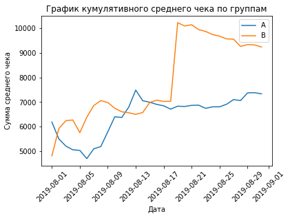

```python
plt.plot(cumulative_data_а['date'], cumulative_data_а['revenue'] / cumulative_data_а['orders'], label='A')
plt.plot(cumulative_data_b['date'], cumulative_data_b['revenue'] / cumulative_data_b['orders'], label='B')
plt.title('График кумулятивного среднего чека по группам')
plt.xticks(rotation=45)
plt.legend()
plt.xlabel('Дата')
plt.ylabel('Сумма среднего чека')
plt.show()
```

На графике кумулятивного среднего чека видны всплески в те же даты, что и по кумулятивной выручке. Для группы А это 13 августа, для группы В 17-19 августа. Теперь мы можем сказать, что в эти дни были сделаны аномально крупные заказы. По группе В средний чек в эти дни возрастает почти на 43%. После всплеска 13 августа средний чек по группе А становится относительно равномерным и плавно растет до конца исследования. По группе В после резкого всплеска 17-19 августа средний чек постепенно снижается до конца исследования. Возможно, необходимо продлить тестирование, до установления стабильных показателей среднего чека по группам.

### График относительного изменения среднего чека группы А к группе В.

Соберем данные по обеим группам в одну таблицу

```python
merge_cumulative_data = cumulative_data_а.merge(cumulative_data_b, on='date', how='left', suffixes=['_a', '_b'])
merge_cumulative_data.head()
```

|  | date | orders_a | revenue_a | orders_b | revenue_b |
| --- | --- | --- | --- | --- | --- |
| 0 | 2019-08-01 | 24 | 148579 | 21 | 101217 |
| 1 | 2019-08-02 | 44 | 242401 | 45 | 266748 |
| 2 | 2019-08-03 | 68 | 354874 | 61 | 380996 |
| 3 | 2019-08-04 | 84 | 425699 | 78 | 489567 |
| 4 | 2019-08-05 | 109 | 549917 | 101 | 581995 |

Построим график

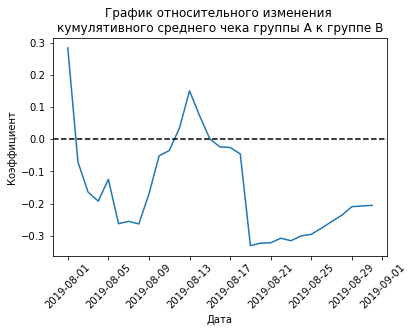

```python
plt.plot(
    merge_cumulative_data['date'],
    (merge_cumulative_data['revenue_a'] / merge_cumulative_data['orders_a']) /
    (merge_cumulative_data['revenue_b'] / merge_cumulative_data['orders_b']) - 1
)

plt.axhline(y=0, color='black', linestyle='--')
plt.title('График относительного изменения \nкумулятивного среднего чека группы А к группе В')
plt.xticks(rotation=45)

plt.xlabel('Дата')
plt.ylabel('Коэффициент')
plt.show()
```

Различие между средними чеками резко "скачет" в тех же точках, что и на предыдущих графиках. Средний чек группы А на 15% превышает средний чек группы В 13 августа, а уже 17-19 августа становится меньше среднего чека по группе В более чем на 30%. Что еще раз подтверждает наличие выбросов в эти даты (аномально крупных заказов). После 19 августа и до конца периода средний чек группы А остается меньше чем у группы В, но это разрыв постепенно сокращается.

### График куммулятивной конверсии по группам.

Посчитаем показатели конверсии для построения графиков.

```python
cumulative_data['conversion'] = cumulative_data['orders'] / cumulative_data['visitors']
cumulative_data_а = cumulative_data[cumulative_data['group'] == 'A']
cumulative_data_b = cumulative_data[cumulative_data['group'] == 'B']
```

Построим график.

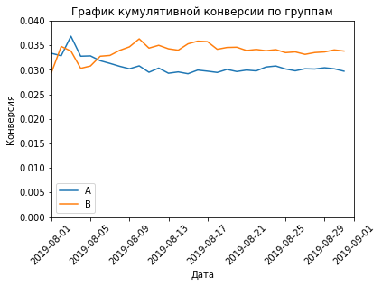

```python
plt.plot(cumulative_data_а['date'], cumulative_data_а['conversion'], label='A')
plt.plot(cumulative_data_b['date'], cumulative_data_b['conversion'], label='B')
plt.title('График кумулятивной конверсии по группам')
plt.xticks(rotation=45)
plt.legend()
plt.xlabel('Дата')
plt.ylabel('Конверсия')
plt.axis(["2019-08-01", '2019-09-01', 0, 0.04])
plt.show()
```

Конверсии становятся относительно стабильными после 17 августа. Конверсия группы В выше конверсии группы А почти весь период исследования.

### График относительного различия кумулятивных конверсий.

Объединим таблицы с конверсиями

```python
merge_cumulative_conv =(
    cumulative_data_а[['date', 'conversion']]
    .merge(cumulative_data_b[['date', 'conversion']], on='date', how='left', suffixes=['_a', '_b'])
)
```

Построим график.

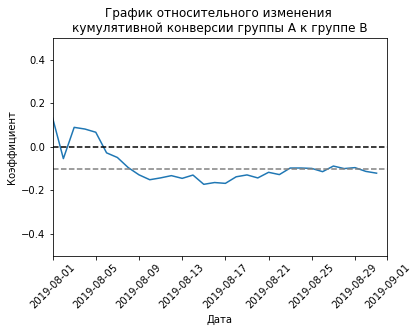

```python
plt.plot(
    merge_cumulative_conv['date'],
    (merge_cumulative_conv['conversion_a'] / merge_cumulative_conv['conversion_b']-1)
)

plt.axhline(y=0, color='black', linestyle='--')
plt.axhline(y=-0.1, color='grey', linestyle='--')
plt.axis(["2019-08-01", '2019-09-01', -0.5, 0.5])
plt.title('График относительного изменения \nкумулятивной конверсии группы А к группе В')
plt.xticks(rotation=45)
plt.xlabel('Дата')
plt.ylabel('Коэффициент')
plt.show()
```

Конверсия группы В лидирует почти весь период теста. После 17 августа конверсия группы А немного улучшается, но все равно стабильно ниже, чем у В.

### Определение аномальных пользователей по количеству заказов.

Посмотрим на количество заказов по пользователеям.

```python
orders_by_visitors =(
    orders
    .groupby('visitor_id', as_index=False)
    .agg({'transaction_id' : 'nunique'})
)
orders_by_visitors.columns=['visitor_id', 'transactions']
orders_by_visitors.sort_values('transactions', ascending=False).head(10)
```

|  | visitor_id | transactions |
| --- | --- | --- |
| 1023 | 4256040402 | 11 |
| 591 | 2458001652 | 11 |
| 569 | 2378935119 | 9 |
| 487 | 2038680547 | 8 |
| 44 | 199603092 | 5 |
| 744 | 3062433592 | 5 |
| 55 | 237748145 | 5 |
| 917 | 3803269165 | 5 |
| 299 | 1230306981 | 5 |
| 897 | 3717692402 | 5 |

Как видно, есть пользователи, совершившие по несколько заказов в исследуемом периоде. Помсмотрим как много таких пользователей построим точечный график распределения числа заказов по пользователям.

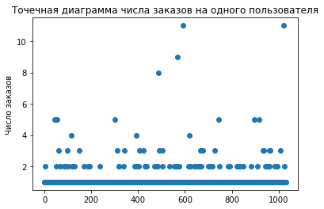

```python
x_values = pd.Series(range(0,len(orders_by_visitors)))

plt.scatter(x_values, orders_by_visitors['transactions'])
plt.title('Точечная диаграмма числа заказов на одного пользователя')
plt.ylabel('Число заказов')
plt.show()
```

На графике видно, что пользователей совершивших от 2-х до 5-ти заказов достаточно много. Для того, чтобы определить, какое количество заказов на одного пользователя считать аномально большим и отнести к выбросам, посчитаем 95 и 99 перцентили количества заказов на одного пользователя.

```python
np.percentile(orders_by_visitors['transactions'], [95, 99])
```

```
array([2., 4.])
```

Не более 5% пользователей совершили больше, чем 2 заказа. И не более 1% пользователей совершили более 4-х заказов. Определим аномальными пользователей, совершивших 3 и более заказа.

### Определение аномальных заказов по сумме.

Построем точечную диаграмму распределения стоимости заказов.

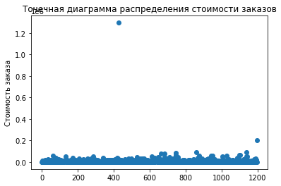

```python
x_values = pd.Series(range(0,len(orders)))

plt.scatter(x_values, orders['revenue'])
plt.title('Точечная диаграмма распределения стоимости заказов')
plt.ylabel('Стоимость заказа')
plt.show()
```

Сумма большинства заказов не превышает 30000, однако есть даже заказ стоимостью свыше 1200000.

Для определения границ за которыми находятся заказы с аномально высокой стоимостью посчитаем 95 и 99 перцентили суммы заказа.

```python
np.percentile(orders['revenue'], [95, 99])
```

```
array([28000. , 58233.2])
```

Не более 5% заказов превышают по сумме 28000, и не более 1% заказов превышают по сумме 58233.

Определим аномальных пользователей, как пользоваттелей, совершивших заказ на сумму 30000 и более.

### Статистическая значимость различий между группами конверсий и средних чеков по "сырым" данным.

Создадим переменные с количеством пользователей в день для каждой группы.

```python
visitors_a_daily = visitors[visitors['group'] == 'A'][['date', 'visitors']]
visitors_a_daily.columns = ['date', 'visitors_per_date_a']

visitors_b_daily = visitors[visitors['group'] == 'B'][['date', 'visitors']]
visitors_b_daily.columns = ['date', 'visitors_per_date_b']
```

Создадим для каждой группы переменные, в которых содержатся данные о пользователях сделавших заказы, с количеством заказов по каждому такому пользователю.

```python
orders_by_visitors_a = (
    orders[orders['group'] == 'A']
    .groupby('visitor_id', as_index=False)
    .agg({'transaction_id': 'nunique'})
)
orders_by_visitors_a.columns = ['visitor_id', 'transactions']

orders_by_visitors_b = (
    orders[orders['group'] == 'B']
    .groupby('visitor_id', as_index=False)
    .agg({'transaction_id': 'nunique'})
)
orders_by_visitors_b.columns = ['visitor_id', 'transactions']
```

**Статистическая значимость различий конверсий.**

Для проверки статистической значимости различий создадим по каждой группе переменные, которые содержат количество заказов, соответствующее каждому пользователю (если пользователь не делал заказ, то число заказов будет обозначено как 0).

```python
sample_a = pd.concat(
    [
        orders_by_visitors_a['transactions'],
        pd.Series(
            0,
            index=np.arange(
                visitors_a_daily['visitors_per_date_a'].sum() - len(orders_by_visitors_a['transactions'])
            ),
            name='transactions',
        ),
    ],
    axis=0,
)

sample_b = pd.concat(
    [
        orders_by_visitors_b['transactions'],
        pd.Series(
            0,
            index=np.arange(
                visitors_b_daily['visitors_per_date_b'].sum() - len(orders_by_visitors_b['transactions'])
            ),
            name='transactions',
        ),
    ],
    axis=0,
)
```

Посмотрим есть ли статистически значимые различия между выборками А и В с количеством заказов на каждого клиента при помощи критерия Манна-Уитни.

**Нулевая гипотеза** - статистически значимых различий в выборках с количеством заказов на каждого клиента между группами А и В нет.

**Альтернативная гипотеза** - статистически значимые различия в выборках с количеством заказов на каждого клиента между группами А и В есть.

```python
alpha=0.05

results =(
    stats.mannwhitneyu(sample_a, sample_b, True, 'two-sided')
)
print('p-значение:', "{0:.3f}".format(results.pvalue))
if results.pvalue < alpha:
    print('Отвергаем нулевую гипотезу')
else:
    print('Не получилось отвергнуть нулевую гипотезу')
```

```
p-значение: 0.017
Отвергаем нулевую гипотезу
```

Вероятность того, что различий в выборках с количеством заказов на каждого клиента между группами А и В нет меньше статистически значимой. Значит у нас есть основания отвергнуть нулевую гипотезу и не отвергать альтернативную.

Посмотрим на относительный прирост конверсии группы В

```python
print(
    'Относительный прирост конверсии группы В по сравнению с группой А',
    "{0:.3f}".format(sample_b.mean() / sample_a.mean() - 1)
)
```

```
Относительный прирост конверсии группы В по сравнению с группой А 0.138
```

По "сырым" данным конверсия у группы В выше почти на 14%.

**Статистическая значимость различий среднего чека**

**Нулевая гипотеза** - статистически значимых различий в среднем чеке между группами А и В нет.

**Альтернативная гипотеза** - статистически значимые различия в среднем чеке между группами А и В есть.

```python
alpha=0.05

results =(
    stats.mannwhitneyu(
        orders[orders['group']=='A']['revenue'],
        orders[orders['group']=='B']['revenue'],
        True, 'two-sided'
    )
)
print('p-значение:', "{0:.3f}".format(results.pvalue))
if results.pvalue < alpha:
    print('Отвергаем нулевую гипотезу')
else:
    print('Не получилось отвергнуть нулевую гипотезу')
```

```
p-значение: 0.729
Не получилось отвергнуть нулевую гипотезу
```

Вероятность того, что статистически значимых различий в среднем чеке между группами А и В нет выше 72%, у нас нет причин отвергать нулевую гипотезу.

Посмотрим на относительное различие в среднем чеке между группами.

```python
print(
    'Относительный прирост среднего чека группы В по сравнению с группой А',
    "{0:.3f}".format(orders[orders['group']=='B']['revenue'].mean() /
                     orders[orders['group']=='A']['revenue'].mean() - 1)
)
```

```
Относительный прирост среднего чека группы В по сравнению с группой А 0.259
```

При том, что проверка критерием Манна-Уитни показала, что с вероятностью более 70% различий в среднем чеке между группами нет, по данным теста средний чек у группы В выше на 26% чем у группы А. Скорее всего это обусловленно наличием выбросов (большим количеством заказов с аномально высокой стоимостью в группе В).

### Статистическая значимость различий между группами конверсий и средних чеков по "очищенным" данным.

Мы решили принять за аномальных пользователей тех, кто совершил 3 заказа и более или заказ на сумму от 30000 и выше. Таким образом, мы уберем от 1 до 5% пользователей с наибольшим числом заказов и от 1 до 5% пользователей с наибольшей суммой заказа.

Узнаем сколько всего у нас аномальных пользователей.

```python
visitors_many_orders =pd.concat(
    [
        orders_by_visitors_a[orders_by_visitors_a['transactions'] >= 3]['visitor_id'],
        orders_by_visitors_b[orders_by_visitors_b['transactions'] >= 3]['visitor_id']
    ], axis=0
)

visitors_expensiv_orders = orders[orders['revenue'] >= 30000]['visitor_id']

abnormal_visitors =(
    pd.concat([visitors_many_orders, visitors_expensiv_orders], axis=0)
    .drop_duplicates()
    .sort_values()
)

print('Аномальные пользователи')
display(abnormal_visitors.head())
print('\n', 'Всего аномальных пользователей', abnormal_visitors.shape)
```

```
Аномальные пользователи
```

```
1099    148427295
18      199603092
928     204675465
23      237748145
37      249864742
Name: visitor_id, dtype: int64
```

```
 Всего аномальных пользователей (68,)
```

Посмотрим попали ли в список аномальных, пользователи, заказы которых есть в обоих группах.

```python
len(set(abnormal_visitors) & set(visitor_in_ab))
```

```
19
```

Убрав аномальных пользователей мы уберем только 19 из 58 поьзователей, заказы которых попали в обе группы.

**Статистическая значимость различий конверсий по "очищенным" данным.**

Подготовим выборки с количеством заказов для пользователей каждой группы без аномальных пользователей.

```python
sample_a_filtered = pd.concat(
    [
        orders_by_visitors_a[
            np.logical_not(orders_by_visitors_a['visitor_id'].isin(abnormal_visitors))
        ]['transactions'],
        pd.Series(
            0,
            index=np.arange(
                visitors_a_daily['visitors_per_date_a'].sum() - len(orders_by_visitors_a['transactions'])
            ),
            name='transactions',
        ),
    ],
    axis=0,
)

sample_b_filtered = pd.concat(
    [
        orders_by_visitors_b[
            np.logical_not(orders_by_visitors_b['visitor_id'].isin(abnormal_visitors))
        ]['transactions'],
        pd.Series(
            0,
            index=np.arange(
                visitors_b_daily['visitors_per_date_b'].sum() - len(orders_by_visitors_b['transactions'])
            ),
            name='transactions',
        ),
    ],
    axis=0,
)
```

Применим критерий Манна-Уитни к полученным выборкам.

**Нулевая гипотеза** - статистически значимых различий в выборках с очищенными данными по количеству заказов на каждого клиента между группами А и В нет.

**Альтернативная гипотеза** - статистически значимые различия в выборках с очищенными данными по количеству заказов на каждого клиента между группами А и В есть.

```python
alpha=0.05

results =(
    stats.mannwhitneyu(sample_a_filtered, sample_b_filtered, True, 'two-sided')
)
print('p-значение:', "{0:.3f}".format(results.pvalue))
if results.pvalue < alpha:
    print('Отвергаем нулевую гипотезу')
else:
    print('Не получилось отвергнуть нулевую гипотезу')
```

```
p-значение: 0.013
Отвергаем нулевую гипотезу
```

Результаты проверки по "очищенным" данным совпадают с результатом, полученным по "сырым" данным. При этом вероятность того, что различий в конверсиях между группами А и В нет стала еще меньше статистически значимой. Значит у нас есть основания отвергнуть нулевую гипотезу и не отвергать альтернативную.

Посмотрим на относительный прирост конверсии группы В по "очищенным" данным.

```python
print(
    'Относительный прирост конверсии группы В по сравнению с группой А',
    "{0:.3f}".format(sample_b_filtered.mean() / sample_a_filtered.mean() - 1)
)
```

```
Относительный прирост конверсии группы В по сравнению с группой А 0.172
```

Конверсия группы B по очищенным данным выше уже на 17%.

**Статистическая значимость различий среднего чека по "очищенным" данным.**

**Нулевая гипотеза** - статистически значимых различий в среднем чеке между группами А и В нет.

**Альтернативная гипотеза** - статистически значимые различия в среднем чеке между группами А и В есть.

```python
alpha=0.05

results =(
    stats.mannwhitneyu(
        orders[
            np.logical_and(
                orders['group']=='A',
                np.logical_not(orders['visitor_id'].isin(abnormal_visitors))
            )
        ]['revenue'],
        orders[
            np.logical_and(
                orders['group']=='B',
                np.logical_not(orders['visitor_id'].isin(abnormal_visitors))
            )
        ]['revenue'],
        True, 'two-sided'
    )
)
print('p-значение:', "{0:.3f}".format(results.pvalue))
if results.pvalue < alpha:
    print('Отвергаем нулевую гипотезу')
else:
    print('Не получилось отвергнуть нулевую гипотезу')
```

```
p-значение: 0.720
Не получилось отвергнуть нулевую гипотезу
```

По "очищенным" данным результат получился, практически таким же, как и по "сырым". Вероятность того, что статистически значимых различий в среднем чеке между группами А и В нет выше 72%, у нас нет причин отвергать нулевую гипотезу.

Посмотрим на относительное различие в среднем чеке между группами по "очищенным данным".

```python
print(
    'Относительный прирост среднего чека группы В по сравнению с группой А',
    "{0:.3f}".format(
        orders[
            np.logical_and(
                orders['group']=='B',
                np.logical_not(orders['visitor_id'].isin(abnormal_visitors))
            )
        ]['revenue']
        .mean() /
        orders[
            np.logical_and(
                orders['group']=='A',
                np.logical_not(orders['visitor_id'].isin(abnormal_visitors))
            )
        ]['revenue']
        .mean() - 1
    )
)
```

```
Относительный прирост среднего чека группы В по сравнению с группой А -0.023
```

По очищенным данным разница в средних чеках всего 2% при чем в пользу группы А. Уменьшение разницы в среднем чеке в "очищенных" данных подтверждает результаты статистического метода Манна-Уитни. Различая в среднем чеке между группами обусловлено лишь наличием выбросов (аномально больших по сумме заказов).

### Решение по результатам А/В теста.

В ходе обзора данных, мы обнаружили 58 пользователей, чьи заказы есть как в группе А, так и в группе В. К результатам данного теста следует относится осторожно, по-возможности провести его повторно.

Анализ А/В теста показал:

- Нет статистически значимых различий в среднем чеке между группами как по "сырым", так и по "очищенным" данным.
- Относительная разница среднего чека по "сырым" данным около 26% в пользу группы B, а по очищенным - всего около 2% в пользу группы А. Можно сделать вывод, что разница в среднем чеке обусловлена наличием выбросов.
- График различия среднего чека очень нестабильный, показывает, что средний чек группы В большую часть периода тестирования выше, чем у группы А. Но это, как мы выяснили результат выбросов (наличия аномально больших по сумме заказов в группе В).
- Статистическая разница между конверсиями групп А и В подтвердилась как по "сырым" данным, так и по данным после фильтрации аномалий.
- Относительная разница в конверсиях между группами по "сырым" данным 14% в пользу группы В. После удаления аномалий разница в пользу группы В составляет уже 17%.
- График различия куммулятивных конверсий между группами показывает, что конверсия группы В стабильно выше конверсии группы А почти весь период теста.

Если не учитыват факт наличия пересекающихся пользователей, на основе имеющихся данных, можно остановить тест и признать его успешным для группы В.